# R Notebook

# Secrets to Happiness from the Crowd

By Huiming Xie

What makes you happy? This question is asked to people 100,000 crowd-sourced happy moments are collected to form HappyDB, by which we perform some exploratory data analysis to parse out what factors make people happy, both as a whole and in groups.

```r
## install and load libraries
packages.used=c("tidyverse", "tidytext","DT", "scales", "wordcloud2", "gridExtra", "ngram",
                "shiny", "igraph", "ggraph", "wordcloud", "RColorBrewer", "plyr", "Hmisc",
                "plotrix", "ggpubr", "ggfortify")
# check packages that need to be installed.
packages.needed=setdiff(packages.used,
                        intersect(installed.packages()[,1],
                                  packages.used))
# install additional packages
if(length(packages.needed)>0){
  install.packages(packages.needed, dependencies = TRUE)
}
# load libraries
library(tidyverse)
library(tidytext)
library(DT)
library(scales)
library(wordcloud2)
library(gridExtra)
library(ngram)
library(shiny)
library(igraph)
library(ggraph)
library(wordcloud)
library(RColorBrewer)
library(plyr)
library(Hmisc)
library(plotrix)
library(ggpubr)
library(ggfortify)
```

```r
# load data for use
hm_data <- read_csv("../output/processed_moments.csv")
urlfile<-'https://raw.githubusercontent.com/rit-public/HappyDB/master/happydb/data/demographic.csv'
demo_data <- read_csv(urlfile)
urlfile2<-'https://raw.githubusercontent.com/rit-public/HappyDB/master/happydb/data/vad.csv'
vad_data <- read_csv(urlfile2)
urladr<-'https://raw.githubusercontent.com/rit-public/HappyDB/master/happydb/data/topic_dict/'
```

```r
# combine two data sets and keep the columns needed
hm_data <- hm_data %>%
  inner_join(demo_data, by = "wid") %>%
  select(hmid,
         wid,
         original_hm,
         gender,
         marital,
         parenthood,
         reflection_period,
         age,
         country,
         ground_truth_category,
         predicted_category,
         text) %>%
  mutate(count = sapply(hm_data$text, wordcount)) %>%
  filter(gender %in% c("m", "f")) %>%
  filter(marital %in% c("single", "married")) %>%
  filter(parenthood %in% c("n", "y")) %>%
  filter(reflection_period %in% c("24h", "3m")) %>%
  mutate(reflection_period = fct_recode(reflection_period,
                                        months_3 = "3m", hours_24 = "24h"))
```

```r
# Create a bag of words using the text data
bag_of_words <-  hm_data %>%
  unnest_tokens(word, text)
word_count <- bag_of_words %>%
  dplyr::count(word, sort = TRUE)
```

```r
#create bigram data
hm_bigrams <- hm_data %>%
  filter(count != 1) %>%
  unnest_tokens(bigram, text, token = "ngrams", n = 2)
bigram_counts <- hm_bigrams %>%
  separate(bigram, c("word1", "word2"), sep = " ") %>%
  dplyr::count(word1, word2, sort = TRUE)
```

```r
#produce a word cloud
set.seed(1)
wordcloud2(data = word_count, shape = 'star', size = 0.6, backgroundColor = "lightsalmon" )
```

[output not shown]

## Most frequent words

```r
# create a lollipop plot of most frequent words
word_count_10 = data.frame(word_count %>%
  slice(1:10) %>%
  mutate(word = reorder(word, n)))
names(word_count_10)[2]="count"

ggdotchart(data=word_count_10,x="word", y="count",
           color = "indianred1",
           sorting = "descending",
           rotate = TRUE,
           dot.size = 9,
           title = "Most Frequent Words",
           label = word_count_10$count,
           font.label = list(color = "black", size = 9,
                             hjust = 1.5),
           add = "segments",
           # add.params = list(color = "lightgray", size = 1.5),
           ggtheme = theme_pubr() )
```

[output not shown]

```r
#bigram plot
bigram_graph <- bigram_counts %>%
  slice(1:50) %>%
  graph_from_data_frame()

  set.seed(123)

  x <- grid::arrow(type = "closed", length = unit(.1, "inches"))

  ggraph(bigram_graph, layout = "fr") +
    geom_edge_link(aes(edge_alpha = n), show.legend = FALSE,
                   arrow = x, end_cap = circle(.05, 'inches')) +
    geom_node_point(color = "lightgreen", size = 3) +
    geom_node_text(aes(label = name), repel = TRUE) +
    theme_void()
```

[output not shown]

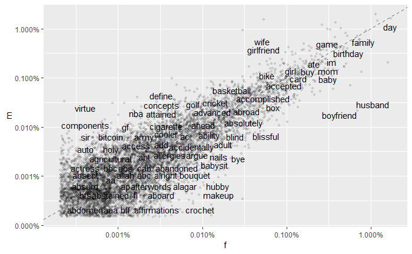

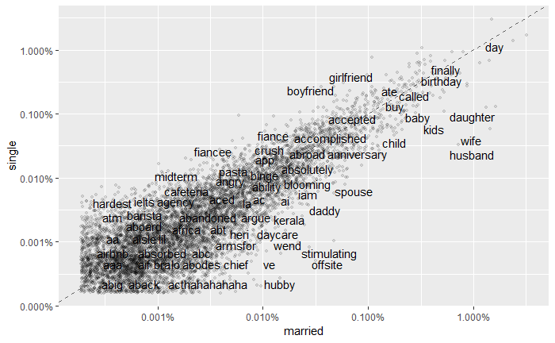

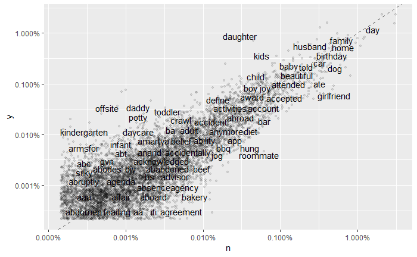

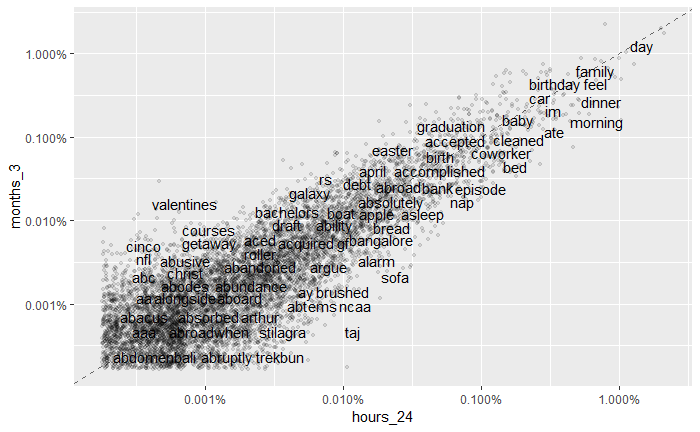

```r
atrs <- c("gender", "marital", "parenthood", "reflection_period")
temp = list()
for(i in 1:length(atrs)){
  temp[[i]] <- bag_of_words %>%
      dplyr::count(!!as.symbol(atrs[i]),word) %>%
      group_by(!!as.symbol(atrs[i])) %>%
      mutate(proportion = n / sum(n)) %>%
      select(-n) %>%
      spread(!!as.symbol(atrs[i]), proportion)
}
comp_of_prop<-function(tmp){
  ggplot(data = tmp,
             aes_string(x = colnames(tmp)[2], y = colnames(tmp)[3]),
             color = abs(colnames(tmp)[3] - colnames(tmp)[2])) +
      geom_abline(color = "gray40", lty = 2) +
      geom_jitter(alpha = 0.1, size = 1, width = 0.3, height = 0.3) +
      geom_text(aes(label = word), check_overlap = TRUE, vjust = 1.5) +
      scale_x_log10(labels = percent_format()) +
      scale_y_log10(labels = percent_format()) +
      scale_color_gradient(limits = c(0, 0.001), low = "darkslategray4", high = "gray75") +
      theme(legend.position="none")
}

lapply(temp, FUN = comp_of_prop)
```

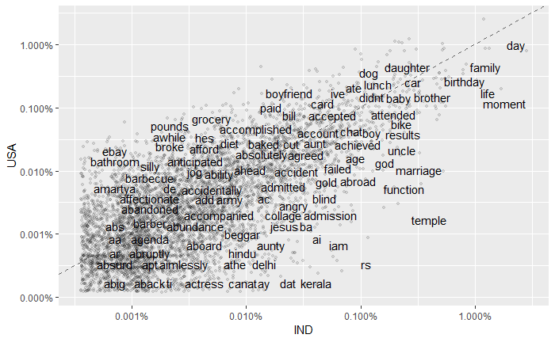

```r
  temp2 <- bag_of_words %>%
      dplyr::count(country,word) %>%
      group_by(country) %>%
      filter(country %in% c("USA", "IND"))%>%
      mutate(proportion = n / sum(n)) %>%
      select(-n) %>%
      spread(country, proportion)
  ggplot(data = temp2,
             aes_string(x = colnames(temp2)[2], y = colnames(temp2)[3]),
             color = abs(colnames(temp2)[3] - colnames(temp2)[2])) +
      geom_abline(color = "gray40", lty = 2) +
      geom_jitter(alpha = 0.1, size = 1, width = 0.3, height = 0.3) +
      geom_text(aes(label = word), check_overlap = TRUE, vjust = 1.5) +
      scale_x_log10(labels = percent_format()) +
      scale_y_log10(labels = percent_format()) +
      scale_color_gradient(limits = c(0, 0.001), low = "darkslategray4", high = "gray75") +
      theme(legend.position="none")
```

```r
NA
```

bigram

```
$`1`

$`2`

attr(,"class")
[1] "list"      "ggarrange"
```

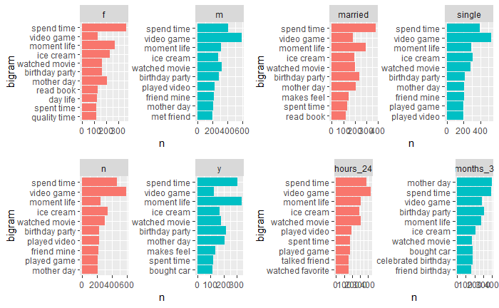

```r
temp3 = list()
pre_order <- function(chrct){
  hm_bigrams %>%
      dplyr::count(!!as.symbol(chrct), bigram, sort = TRUE) %>%
      group_by(!!as.symbol(chrct)) %>%
      top_n(10) %>%
      ungroup() %>%
      mutate(bigram = reorder(bigram, n))
}
temp3 = alply( as.matrix(atrs,ncol=1,nrow=4),1,pre_order)
comp_of_bigram<-function(tmp){
  ggplot(data = tmp,
             aes(bigram, n, fill = !!as.symbol(colnames(tmp)[1]))) +
      geom_col(show.legend = FALSE) +
      facet_wrap(as.formula(paste("~", colnames(tmp)[1])), ncol = 2, scales = "free") +
      coord_flip()
}
plt = lapply(temp3, FUN = comp_of_bigram)
ggarrange(plt[[1]],plt[[2]], plt[[3]], plt[[4]], plt, common.legend=FALSE,legend = 'right', nrow=2, ncol=2)
```

```r
countries = sort(table(demo_data$country), decreasing = TRUE)
main_countries = c(countries[1:2],sum(countries[-c(1,2)]))
names(main_countries)=c("USA", "India","Others")
main_countries = round(main_countries/sum(main_countries), digits = 3)
pie3D(main_countries,labels=paste(names(main_countries),sep=""),radius = 0.9, main="Countries of Respondents ",col=c("brown","orange","yellow"), labelcex = 1.5)
```

[output not shown]

specify ordinal number of indians

```r
temp4 <- hm_bigrams %>%
  dplyr::count(country, bigram, sort = TRUE) %>%
  group_by(country) %>%
  filter(country %in% c("USA", "IND"))%>%
  top_n(10) %>%
  ungroup() %>%
  mutate(bigram = reorder(bigram, n))


ggplot(data = temp4,
       aes(bigram, n, fill = country)) +
  geom_col(show.legend = FALSE) +
  facet_wrap(as.formula(paste("~", "country")), ncol = 2, scales = "free") +
  coord_flip()
```

[output not shown]

add predicted category and vad data to the hm_data

```r
hm_data <- hm_data %>%
  inner_join(vad_data, by = "hmid") %>%
  select(hmid,
         wid,
         original_hm,
         gender,
         marital,
         parenthood,
         reflection_period,
         age,
         country,
         ground_truth_category,
         predicted_category,
         text,
         valency,
         dominance,
         arousal)
```

```r
pred_cat = hm_data[,c(4:7,9,11)]
pred_cat$predicted_category = factor(hm_data$predicted_category,
                                     levels = rev(c("achievement", "affection", "bonding",
                                                "enjoy_the_moment","leisure","nature","exercise")))

ggplot(data = pred_cat)+
  geom_bar(aes(x=predicted_category))+
  coord_flip()+
  labs(title = "Predicted Category Frequency", x = "Category", y = "Frequency")

pred_cat_table = as.data.frame(sort(table(pred_cat$predicted_category), decreasing = TRUE))
names(pred_cat_table)[1]="category"

ggplot(data = pred_cat_table, aes(x=factor(1), y=Freq, fill=category))+
  geom_bar(width=1, stat="identity")+
  coord_polar(theta = "y")+
  labs(title = "Predicted Category Frequency", x = "Category", y = "Frequency")
```

[output not shown]

```r
atrs <- c("gender", "marital", "parenthood", "reflection_period")
temp0 = list()
sql_cat = list()
for (i in 1:length(atrs)){
  sql_cat[[i]] = pred_cat%>%
                   dplyr::count(!!as.symbol(atrs[i]),predicted_category)%>%
                   group_by(!!as.symbol(atrs[i]),predicted_category)
}
sql_cat[[5]] = pred_cat%>%
  dplyr::count(country,predicted_category)%>%
  group_by(country,predicted_category)%>%
  filter(country %in% c("USA","IND"))
atrs[5]="country"
names(sql_cat)=atrs
divi <-function(vec,df){
  vec1 = as.vector(vec)
  if (as.character(vec1[1])==as.character(df[1,1])){
    vec1[3]=as.numeric(vec1[3])/as.numeric(df[1,2])
  }
  else{
    vec1[3]=as.numeric(vec1[3])/as.numeric(df[2,2])
  }
  return(vec1[3])
}
cnt_to_prop<-function(df){
  df = data.frame(df)
  df_sum = df%>%
    group_by(!!as.symbol(names(df)[1]))%>%
    dplyr::summarise(total = sum(n, na.rm = TRUE))
  df_sum = data.frame(df_sum)
  props = round(as.numeric(apply(df,1,divi,df_sum)),digits = 4)
  df[,3] = props
  names(df)[3]="proportion"
  return(df)
}
gen = data.frame(sql_cat[[1]])
#try
ttt = data.frame(data.frame(sql_cat[[1]])%>%
    group_by(gender)%>%
    dplyr::summarise(total = sum(n)))

cnt_to_prop(data.frame(sql_cat[[1]]))
```

```
   gender predicted_category proportion
1       f           exercise     0.0089
2       f             nature     0.0209
3       f            leisure     0.0619
4       f   enjoy_the_moment     0.1026
5       f            bonding     0.0995
6       f          affection     0.4096
7       f        achievement     0.2966
8       m           exercise     0.0143
9       m             nature     0.0161
10      m            leisure     0.0838
11      m   enjoy_the_moment     0.1165
12      m            bonding     0.1124
13      m          affection     0.2905
14      m        achievement     0.3663
```

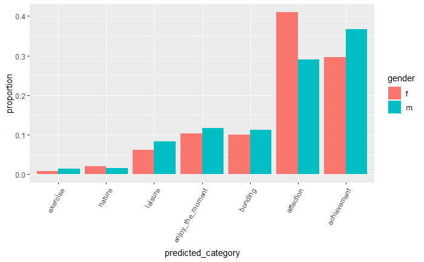

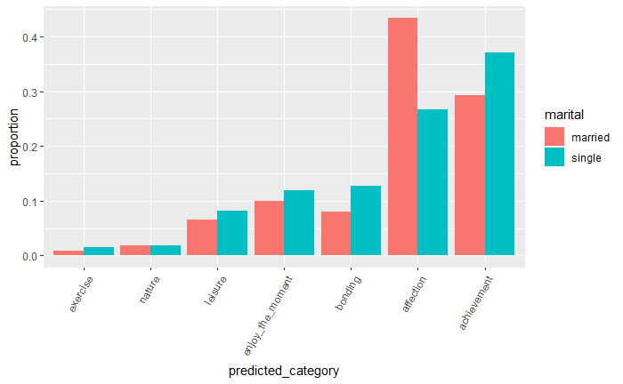

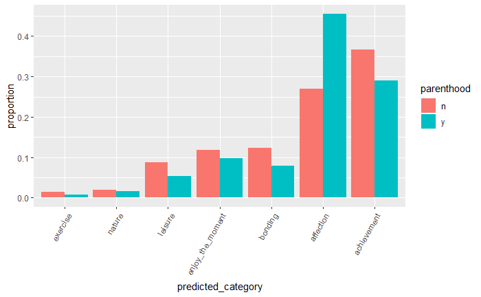

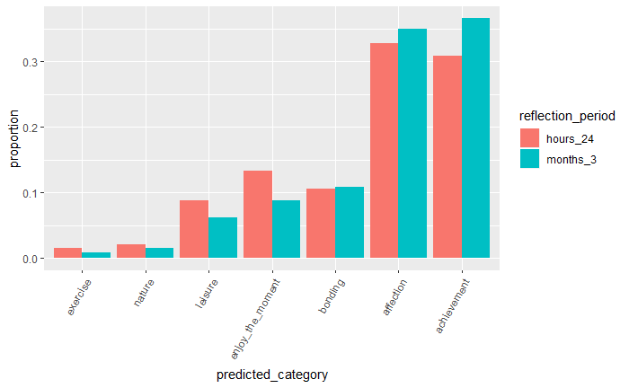

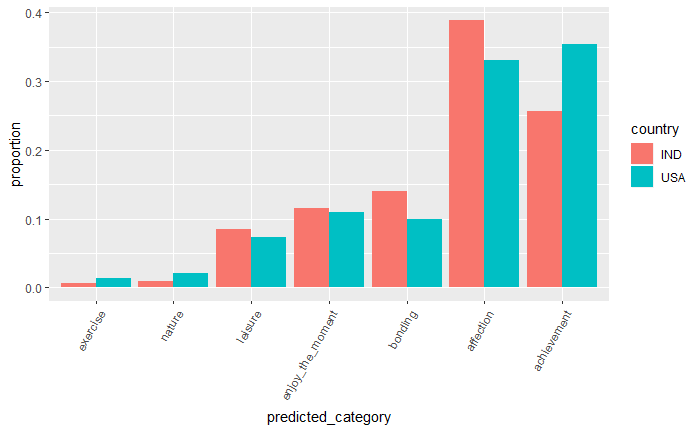

```r
bi_cat<-function(df){
  df = cnt_to_prop(df)
  ggplot(data=df, aes(x=!!as.symbol(names(df)[2]),y=!!as.symbol(names(df)[3])))+
    geom_bar(aes(fill=!!as.symbol(names(df)[1])), position = "dodge", stat="identity")+
    theme(axis.text.x = element_text(angle = 60, hjust = 1))
}
lapply(sql_cat, FUN = bi_cat )
```

```r
# urladr<-'https://raw.githubusercontent.com/rit-public/HappyDB/master/happydb/data/topic_dict/'
dict_vec = c("entertainment", "exercise", "family", "food", "people", "pets","school", "shopping", "work")
load_dict<-function(dict){
  return(read.csv(paste(urladr,dict,"-dict.csv", sep = ""),header = FALSE))
}
dict_list = apply(matrix(dict_vec,nrow=length(dict_vec),ncol=1),1,load_dict)
dict_list = plyr::alply(matrix(dict_vec,nrow=length(dict_vec),ncol=1),1,load_dict)
names(dict_list) = dict_vec
txt = as.vector(hm_data$text)
txt = paste(txt, collapse = " ")
wd = strsplit(txt, split = " ")[[1]]
txt_table = table(wd)
txt_df = as.data.frame(txt_table)
count_key<-function(key, cnt, txt_df){
  if (key %in% txt_df[,1]){
    return(txt_df[which(txt_df[,1]==key),2])
  }
  else{
    return(0)
  }
}
count_dict<-function(df, txt_df){
  cnt = 0
  cnt_vec = apply(as.matrix(df), 1, count_key, cnt, txt_df)
  return(sum(cnt_vec))
}
dict_count = sort(sapply(dict_list, FUN = count_dict, txt_df), decreasing = TRUE)

dict_expand = as.data.frame(rep(names(dict_count),dict_count))
head(dict_count)
```

```
       people        family          food entertainment          work      exercise
        54664         32150         28292         10575          9896          9030
```

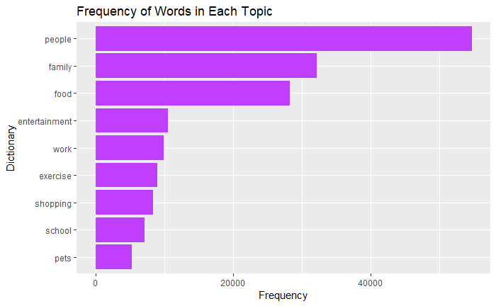

```r
names(dict_expand)="words"
dict_expand$words <- factor(dict_expand$words, levels = rev(names(dict_count)))
ggplot(data = dict_expand)+
  geom_bar(aes(x=words),fill = "darkorchid1")+
  labs(x="Dictionary", y="Frequency", title = "Frequency of Words in Each Topic")+
  coord_flip()
```

```r
atrs <- c("gender", "marital", "parenthood", "reflection_period")
temp5 = list()
for(i in 1:length(atrs)){
  temp5[[i]] <- bag_of_words %>%
      dplyr::count(!!as.symbol(atrs[i]),word) %>%
      group_by(!!as.symbol(atrs[i])) %>%
      mutate(cnt = n) %>%
      select(-n)
      # spread(!!as.symbol(atrs[i]),value)
}

temp5[[5]] <- bag_of_words%>%
      dplyr::count(country,word) %>%
      group_by(country) %>%
      filter(country %in% c("USA","IND"))%>%
      mutate(cnt = n) %>%
      select(-n)

atrs = c(atrs, "country")
names(temp5) = atrs
#temp5 is a list of 4 dataframes counting words in each group

pre_split<-function(df){
  return(split(df[,2:3],f=df[,1]))
}
#split a dataframe into a list of 2 dataframes

atr_lists=lapply(temp5, FUN = pre_split)
#atr_lists is a list of 4 lists of 2 dataframes counting words in each group


comp_dict<-function(df){
  txt_df = df
  dict_cnt = sort(sapply(dict_list, FUN = count_dict, as.data.frame(txt_df)), decreasing = TRUE)
  return(dict_cnt)
}

sublist<-function(lst){
  dict_cnt_l = lapply(lst, FUN = comp_dict)
  return(dict_cnt_l)
}

comp_output = lapply(atr_lists, FUN = sublist)

tblst_to_df<-function(tblst){
  nm= NA

  df1=as.data.frame(rep(names(tblst[[1]]),tblst[[1]]))
  names(df1)="dicts"
  df1$gp = names(tblst)[1]
  df2=as.data.frame(rep(names(tblst[[2]]),tblst[[2]]))
  names(df2)="dicts"
  df2$gp = names(tblst)[2]
  df = rbind(df1, df2)

  if(names(tblst)[1]=="f"){
    nm=atrs[1]
  }
  else if(names(tblst)[1]=="married"){
    nm=atrs[2]
  }
  else if(names(tblst)[1]=="n"){
    nm=atrs[3]
  }
  else if(names(tblst)[1]=="hours_24"){
    nm=atrs[4]
  }
  else if(names(tblst)[1]=="IND"){
    nm=atrs[5]
  }

  names(df)[2]=nm
  return(df)
}

comp_dict_plot<-function(lst2){
  df_mix = tblst_to_df(lst2)
  df_mix$dicts = factor(df_mix$dicts,levels = rev(names(comp_output[[1]][[1]])))

  ggplot(data = df_mix)+
  geom_bar(aes(x=dicts, fill=!!as.symbol(names(df_mix)[2])))+
  facet_wrap(as.formula(paste("~", names(df_mix)[2])), ncol = 2, scales = "free")+
  coord_flip()+
  labs(title = "Frequency of Words in Each Topic", x = "Dictionary", y = "Frequency")+
  scale_fill_manual(values=c("#CC6666", "#66CC99"))
}

lapply(comp_output, FUN = comp_dict_plot)
```

[output not shown]

vad valence (the pleasantness of a stimulus): arousal (the intensity of emotion provoked by a stimulus), dominance (the degree of control exerted by a stimulus)

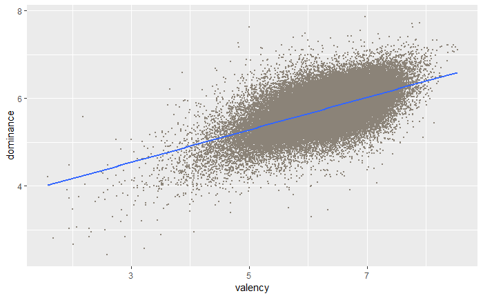

```r
ggplot(data=hm_data)+
  geom_jitter(aes(x=valency, y=dominance), size =0.1, color = "antiquewhite4")+
  stat_smooth(aes(x=valency, y=dominance),method = "lm", formula = y ~ x, size = 1)
```

```
There were 21 warnings (use warnings() to see them)
```

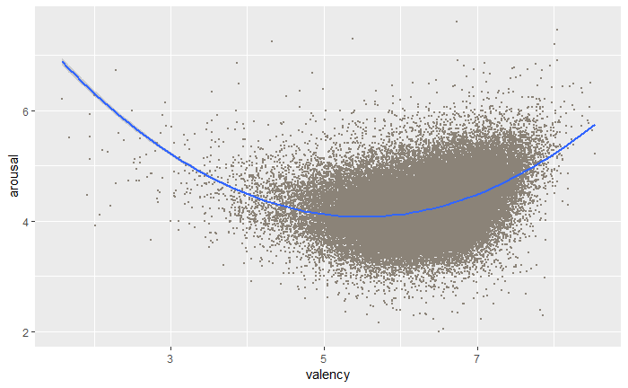

```r
ggplot(data=hm_data)+
  geom_jitter(aes(x=valency, y=arousal), size =0.1, color = "antiquewhite4")+
  stat_smooth(aes(x=valency, y=arousal),method = "lm", formula = y ~ x + I(x^2), size = 1)
```

? explore why there is a quadratic trend

? why happy moments expressed whith low valency one man’s meat is another man’s poison low_val: ppl in adversity happiness is relative

?high valency: universal happiness?

?low arousal: happiness can be very simple and subtle

```r
low_val = head(hm_data[order(hm_data$valency,decreasing = FALSE),]$original_hm,10)
low_val
```

```
 [1] "I planned out my suicide."
 [2] "I got recovered from the disease i had"
 [3] "getting out of jail"
 [4] "i was released from jail."
 [5] "Paid off all my bills and caught up on all my debt"
 [6] "I paid off all my debt"
 [7] "I paid off some of my debt today"
 [8] "I got over my illness"
 [9] "I paid off my debt."
[10] "finished paying off a looming debt that i had been struggling with for several years."
```

```r
# happiness arise from pain
high_val=  head(hm_data[order(hm_data$valency,decreasing = TRUE),]$original_hm,10)
high_val
```

```
 [1] "I found out I was going to florida for vacation."
 [2] "I went on vacation in Rome"
 [3] "We are going to Goa for our vacation. Tickets confirmed."
 [4] "I planned out my next vacation."
 [5] "I remembered that I'm on vacation in a few weeks."
 [6] "Planned a vacation to Philadelphia"
 [7] "Booked a vacation with friends."
 [8] "It was when we went to Florida for vacation."
 [9] "I went on vacation to Santiago."
[10] "We were heading out on vacation with some friends."
```

```r
#real happiness
low_aro = head(hm_data[order(hm_data$arousal,decreasing = FALSE),]$original_hm,10)
low_aro
```

```
 [1] "My kitty fell asleep in my arms."
 [2] "I fell asleep next to her."
 [3] "I went to starbucks and ordered a tea I hadn't tried before and I actually liked it"
 [4] "I bought Boba Tea"
 [5] "Made some tea."
 [6] "I level up in games"
 [7] "I completed another level of Spanish on Duolingo."
 [8] "I went whitewater rafting in North Carolina."
 [9] "I went zip-lining in North Carolina."
[10] "I met Lebron James and he gave t-shirt"
```

[output not shown]

```
$`1`

$`2`

attr(,"class")
[1] "list"      "ggarrange"
```

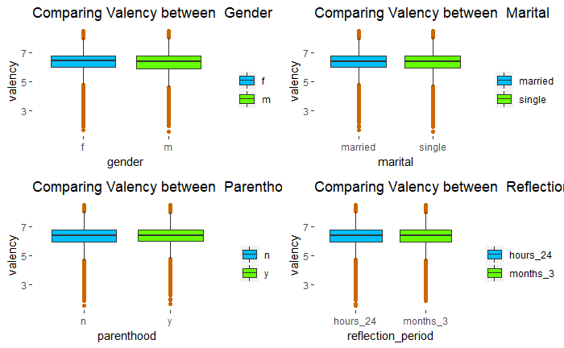

```r
atrs_matrix = as.matrix(atrs[-5])
comp_box<-function(chrct){
  ggplot(hm_data,aes(x=!!as.symbol(chrct), y = valency, fill = !!as.symbol(chrct)))+
  geom_boxplot(notch = FALSE, outlier.colour="#CC6600")+
  scale_fill_manual(name = "", values = c("#00BFFF", "#66FF00")) +
  theme(panel.background = element_rect(fill = 'white' )) +
  ggtitle(paste("Comparing Valency between ", capitalize(chrct)))
}
plt = apply(atrs_matrix,1,comp_box)
ggarrange(plt[[1]],plt[[2]], plt[[3]], plt[[4]], plt, common.legend=FALSE,legend = 'right', nrow=2, ncol=2)
```

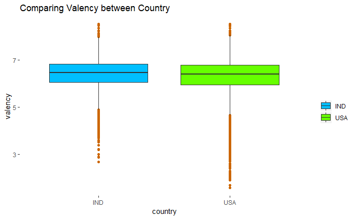

```r
country_vad = hm_data%>%
  select(country,
         valency,
         arousal,
         dominance)%>%
  filter(country %in% c("USA","IND"))
ggplot(country_vad,aes(x=country, y = valency, fill = country))+
  geom_boxplot(notch = FALSE, outlier.colour="#CC6600")+
  scale_fill_manual(name = "", values = c("#00BFFF", "#66FF00")) +
  theme(panel.background = element_rect(fill = 'white' )) +
  ggtitle(paste("Comparing Valency between Country"))
```

lower tail in usa

```r
# vad_data <- read_csv(urlfile2)
vad_data = data.frame(vad_data)
vad_data = cbind(vad_data[,1:2],vad_data$arousal,vad_data$dominance)
vad_ori = stats::na.omit(vad_data)
vad = vad_ori
vad[,2:4]= scale(vad_ori[,2:4])
# Determine number of clusters
hmid_vad = vad[,1]
va = vad[,2:3]
# K-Means Cluster Analysis
set.seed(1)
fit <- kmeans(va, 3) # 3 cluster solution
km_vad <- data.frame(vad_ori, fit$cluster)
names(km_vad)[3:5] = c("arousal","dominance","subjective_group")
km_vad[which(km_vad[,5]==2),5]=0
km_vad[which(km_vad[,5]==1),5]=2
km_vad[which(km_vad[,5]==0),5]=1
head(km_vad)
```

```
    hmid  valency  arousal dominance subjective_group
1  31526 6.614000 3.750000  5.840000                2
2  37050 5.663158 3.983947  5.461579                3
3  46196 5.440000 4.661500  5.364000                3
5  55093 6.195714 4.118571  5.657143                2
6  89517 6.569000 4.647000  5.671000                1
7 100127 7.346250 4.968750  6.151250                1
```

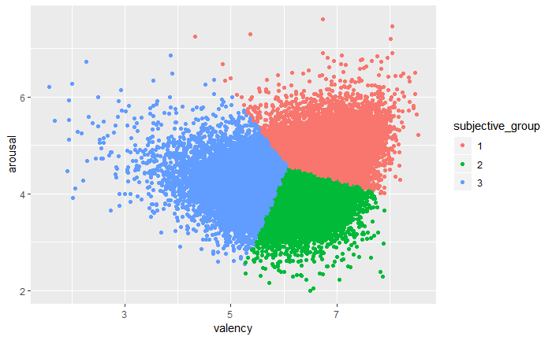

```r
km_vad$subjective_group = as.factor(km_vad$subjective_group)
# head(va)
# plot(km_vad[,2:3], col = km_vad$cluster)
ggplot(data = km_vad,aes(x=valency,y=arousal))+
  geom_point()+
  geom_point(aes(colour = subjective_group))
```

```r
# km_vad
vad_age = data.frame(hm_data)[,-c(13,14,15)]%>%
  inner_join(km_vad, by="hmid")%>%
  select(hmid,
         age,
         valency,
         arousal,
         dominance,
         subjective_group)
vad_age$age = as.numeric(vad_age$age)
```

```
NAs introduced by coercion
```

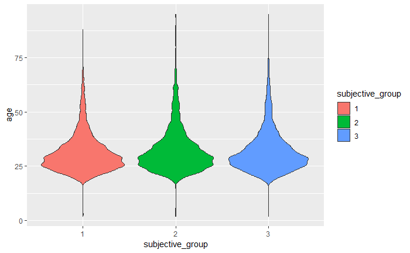

```r
vad_age = stats::na.omit(vad_age)
vad_age = vad_age[vad_age$age < 100,]
ggplot(vad_age,aes(x=subjective_group, y = age))+
 geom_violin(aes(fill = subjective_group))
```

```r
cat_vad = hm_data%>%
  inner_join(km_vad, by="hmid")%>%
  select(hmid,
         predicted_category,
         subjective_group)
cat_vad_cnt = data.frame(cat_vad%>%
  group_by(subjective_group)%>%
  dplyr::count(predicted_category))
cat_vad_cnt[,1]=factor(cat_vad_cnt[,1])
head(cat_vad_cnt)
```

```
  subjective_group predicted_category     n
1                1        achievement  7564
2                1          affection 13308
3                1            bonding  3166
4                1   enjoy_the_moment  3514
5                1           exercise   401
6                1            leisure  2302
```

```r
cnt_lst = split(cat_vad_cnt, f=cat_vad_cnt$subjective_group)
cnt_lst
```

```
$`1`
  subjective_group predicted_category     n
1                1        achievement  7564
2                1          affection 13308
3                1            bonding  3166
4                1   enjoy_the_moment  3514
5                1           exercise   401
6                1            leisure  2302
7                1             nature   384

$`2`
   subjective_group predicted_category     n
8                 2        achievement 12834
9                 2          affection 15217
10                2            bonding  4864
11                2   enjoy_the_moment  5400
12                2           exercise   451
13                2            leisure  3169
14                2             nature  1136

$`3`
   subjective_group predicted_category     n
15                3        achievement 11105
16                3          affection  3444
17                3            bonding  1964
18                3   enjoy_the_moment  1471
19                3           exercise   263
20                3            leisure  1267
21                3             nature   175
```

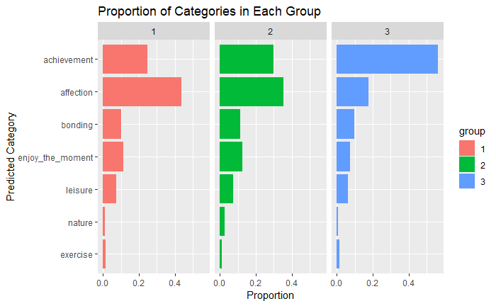

```r
cnt_df = NULL
for(i in 1:3){
  cnt_lst[[i]]$proportion = round(cnt_lst[[i]]$n/sum(cnt_lst[[i]]$n),4)
  cnt_lst[[i]] = cnt_lst[[i]][,-3]
  names(cnt_lst[[i]])[1]="group"
  cnt_df = rbind(cnt_df, cnt_lst[[i]])
}
cnt_df$predicted_category = factor(cnt_df$predicted_category, levels = rev(c("achievement", "affection", "bonding", "enjoy_the_moment","leisure","nature","exercise")))
ggplot(data = cnt_df, aes(x=predicted_category,y=proportion,fill=group))+
  geom_bar(stat = "identity")+
  facet_wrap(as.formula("~group"), ncol = 3)+
  coord_flip()+
  labs(title = "Proportion of Categories in Each Group", x = "Predicted Category", y = "Proportion")
```

```r
vad_bag = data.frame(bag_of_words)%>%
  inner_join(km_vad, by = "hmid")%>%
  select(hmid, word, subjective_group)
wc_vad = data.frame(vad_bag%>%
  group_by(subjective_group)%>%
  dplyr::count(word))
wc_vad_lists = pre_split(wc_vad)
op = sublist(wc_vad_lists)
op_df_lst = lapply(op, as.data.frame)
op_df_lst[[1]]$dicts = row.names(op_df_lst[[1]])
 op_df_lst
```

```
$`1`
              X[[i]]         dicts
people         19871        people
family         12000        family
food            9287          food
entertainment   4016 entertainment
shopping        2794      shopping
exercise        2468      exercise
work            2161          work
pets            2126          pets
school          1385        school

$`2`
              X[[i]]
people         27946
family         17124
food           16949
entertainment   5533
exercise        4781
shopping        4230
work            4086
school          3393
pets            2402

$`3`
              X[[i]]
people          6646
work            3628
family          2967
school          2380
food            1932
exercise        1722
shopping        1219
entertainment    977
pets             695
```

```r
op_df = NULL
for (i in 1:3){
  op_df_lst[[i]]$dicts = row.names(op_df_lst[[i]])
  op_df_lst[[i]]$group = i
  names(op_df_lst[[i]])[1]="proportion"
  op_df_lst[[i]]$proportion = round(op_df_lst[[i]]$proportion/sum(op_df_lst[[i]]$proportion),digits = 4)
  op_df = rbind(op_df,op_df_lst[[i]])
}
op_df_lst
```

```
$`1`
              proportion         dicts group
people            0.3542        people     1
family            0.2139        family     1
food              0.1655          food     1
entertainment     0.0716 entertainment     1
shopping          0.0498      shopping     1
exercise          0.0440      exercise     1
work              0.0385          work     1
pets              0.0379          pets     1
school            0.0247        school     1

$`2`
              proportion         dicts group
people            0.3233        people     2
family            0.1981        family     2
food              0.1961          food     2
entertainment     0.0640 entertainment     2
exercise          0.0553      exercise     2
shopping          0.0489      shopping     2
work              0.0473          work     2
school            0.0393        school     2
pets              0.0278          pets     2

$`3`
              proportion         dicts group
people            0.2998        people     3
work              0.1637          work     3
family            0.1339        family     3
school            0.1074        school     3
food              0.0872          food     3
exercise          0.0777      exercise     3
shopping          0.0550      shopping     3
entertainment     0.0441 entertainment     3
pets              0.0314          pets     3
```

```r
op_df
```

```
               proportion         dicts group
people             0.3542        people     1
family             0.2139        family     1
food               0.1655          food     1
entertainment      0.0716 entertainment     1
shopping           0.0498      shopping     1
exercise           0.0440      exercise     1
work               0.0385          work     1
pets               0.0379          pets     1
school             0.0247        school     1
people1            0.3233        people     2
family1            0.1981        family     2
food1              0.1961          food     2
entertainment1     0.0640 entertainment     2
exercise1          0.0553      exercise     2
shopping1          0.0489      shopping     2
work1              0.0473          work     2
school1            0.0393        school     2
pets1              0.0278          pets     2
people2            0.2998        people     3
work2              0.1637          work     3
family2            0.1339        family     3
school2            0.1074        school     3
food2              0.0872          food     3
exercise2          0.0777      exercise     3
shopping2          0.0550      shopping     3
entertainment2     0.0441 entertainment     3
pets2              0.0314          pets     3
```

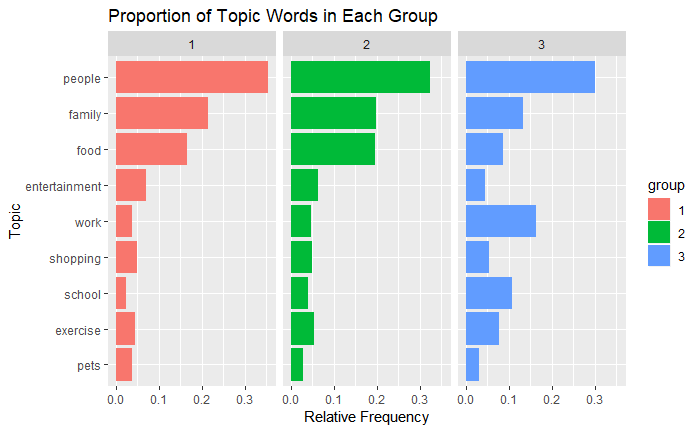

```r
op_df$group=as.factor(op_df$group)
op_df$dicts = factor(op_df$dicts,levels = rev(names(comp_output[[1]][[1]])))
ggplot(data = op_df,aes(x=dicts,y=proportion, fill=group))+
  geom_bar(stat = "identity")+
  facet_wrap(as.formula("~group"), ncol = 3)+
  coord_flip()+
  labs(title = "Proportion of Topic Words in Each Group", x = "Topic", y = "Relative Frequency")
```

```r
datatable(hm_data)
```

```r
@inproceedings{asai2018happydb,
  title = {HappyDB: A Corpus of 100,000 Crowdsourced Happy Moments},
  author = {Asai, Akari and Evensen, Sara and Golshan, Behzad and Halevy, Alon
  and Li, Vivian and Lopatenko, Andrei and Stepanov, Daniela and Suhara, Yoshihiko
  and Tan, Wang-Chiew and Xu, Yinzhan},
  booktitle = {Proceedings of LREC 2018},
  month = {May},   year={2018},
  address = {Miyazaki, Japan},
  publisher = {European Language Resources Association (ELRA)}
}
```